# exam_radon

2025-11-24

# Init

```r
library(emmeans)
library(multcomp)
library(lme4)
library(lmerTest)
```

```r
library(ggplot2)
library(dplyr)
library(predictmeans)
library(lattice) # to visualize random effects
```

```r
# setwd("C:/Users/huste/Documents/Github/businessAnalytics/Correlated Data/Exam")
setwd("/home/husted42/Documents/github/businessAnalytics/Correlated Data/Exam/")

getwd()
```

```
## [1] "/home/husted42/Documents/github/businessAnalytics/Correlated Data/Exam"
```

```r
list.files()
```

```
## [1] "radon_code_files" "radon_code.html"  "radon_code.Rmd"   "Radon_data.R"
## [5] "Radon_MN.csv"     "rat_code.html"    "rat_code.Rmd"     "Rats_Box.txt"
```

```r
df<-read.table("Radon_MN.csv",header = T)
head(df)
```

```
##   idnum state state2 stfips   zip region typebldg floor room basement windoor
## 1  5081    MN     MN     27 55735      5        1     1    3        N      NA
## 2  5082    MN     MN     27 55748      5        1     0    4        Y      NA
## 3  5083    MN     MN     27 55748      5        1     0    4        Y      NA
## 4  5084    MN     MN     27 56469      5        1     0    4        Y      NA
## 5  5085    MN     MN     27 55011      3        1     0    4        Y      NA
## 6  5086    MN     MN     27 55014      3        1     0    4        Y      NA
##   rep stratum wave starttm stoptm startdt stopdt activity pcterr     adjwt
## 1   2       4   41     930    930   12088  12288      2.2    9.7 1146.4992
## 2   5       2   40    1615   1615   11888  12088      2.2   14.5  471.3662
## 3   3       2   42    1030   1515   20288  21188      2.9    9.6  433.3167
## 4   2       2   24    1410   1410  122987 123187      1.0   24.3  461.6237
## 5   3       2   40     600    600   12888  13088      3.1   13.8  433.3167
## 6   5       2   22     900   1300  120287 121187      2.5   12.8  471.3662
##   dupflag zipflag cntyfips county x          county.name         y     u.full
## 1       1       0        1      1 1 AITKIN               0.7884574 -0.6890476
## 2       0       0        1      1 0 AITKIN               0.7884574 -0.6890476
## 3       0       0        1      1 0 AITKIN               1.0647107 -0.6890476
## 4       0       0        1      1 0 AITKIN               0.0000000 -0.6890476
## 5       0       0        3      2 0 ANOKA                1.1314021 -0.8473129
## 6       0       0        3      2 0 ANOKA                0.9162907 -0.8473129
```

# I. Exploratory analysis

```r
df$county <- as.factor(df$county)
df$floor <- as.factor(df$floor)
unique(df$county)
```

```
##  [1] 1  2  3  4  5  6  7  8  9  10 11 12 13 14 15 16 17 18 19 20 21 22 23 24 25
## [26] 26 27 28 29 30 31 32 33 34 35 36 37 38 39 40 41 42 43 44 45 46 47 48 49 50
## [51] 51 52 53 54 55 56 57 58 59 60 61 62 63 64 65 66 67 68 69 70 71 72 73 74 75
## [76] 76 77 78 79 80 81 82 83 84 85
## 85 Levels: 1 2 3 4 5 6 7 8 9 10 11 12 13 14 15 16 17 18 19 20 21 22 23 ... 85
```

```r
unique(df$floor)
```

```
## [1] 1 0
## Levels: 0 1
```

```r
summary(df$u)
```

```
##     Min.  1st Qu.   Median     Mean  3rd Qu.     Max.
## -0.88183 -0.47467 -0.09652 -0.13171  0.18324  0.52802
```

```r
summary(df$y)
```

```
##    Min. 1st Qu.  Median    Mean 3rd Qu.    Max.
## -2.3026  0.6419  1.2809  1.2246  1.7918  3.8754
```

We see that there are 85 different counties and floor is a binary variable 0 meaning basement and 1 meaning not basement.

```r
xtabs(~ county, df)
```

```
## county
##   1   2   3   4   5   6   7   8   9  10  11  12  13  14  15  16  17  18  19  20
##   4  52   3   7   4   3  14   4  10   6   5   4   6  14   4   2   4  12  63   3
##  21  22  23  24  25  26  27  28  29  30  31  32  33  34  35  36  37  38  39  40
##   9   6   2   9  14 105   6   5   3  11   5   4   4   3   7   2   9   4   5   4
##  41  42  43  44  45  46  47  48  49  50  51  52  53  54  55  56  57  58  59  60
##   8   1   9   7  13   5   2   9  13   1   4   3   3  23   8   3   6   4   4   2
##  61  62  63  64  65  66  67  68  69  70  71  72  73  74  75  76  77  78  79  80
##  32   5   3  11   2  14  13   8   4 116  25  10   2   4   3   4   7   5   4  46
##  81  82  83  84  85
##   3   1  13  13   2
```

The data is not balanced

```r
xtabs(~ county, df)
```

```
## county
##   1   2   3   4   5   6   7   8   9  10  11  12  13  14  15  16  17  18  19  20
##   4  52   3   7   4   3  14   4  10   6   5   4   6  14   4   2   4  12  63   3
##  21  22  23  24  25  26  27  28  29  30  31  32  33  34  35  36  37  38  39  40
##   9   6   2   9  14 105   6   5   3  11   5   4   4   3   7   2   9   4   5   4
##  41  42  43  44  45  46  47  48  49  50  51  52  53  54  55  56  57  58  59  60
##   8   1   9   7  13   5   2   9  13   1   4   3   3  23   8   3   6   4   4   2
##  61  62  63  64  65  66  67  68  69  70  71  72  73  74  75  76  77  78  79  80
##  32   5   3  11   2  14  13   8   4 116  25  10   2   4   3   4   7   5   4  46
##  81  82  83  84  85
##   3   1  13  13   2
```

```r
xtabs(~ floor, df)
```

```
## floor
##   0   1
## 766 153
```

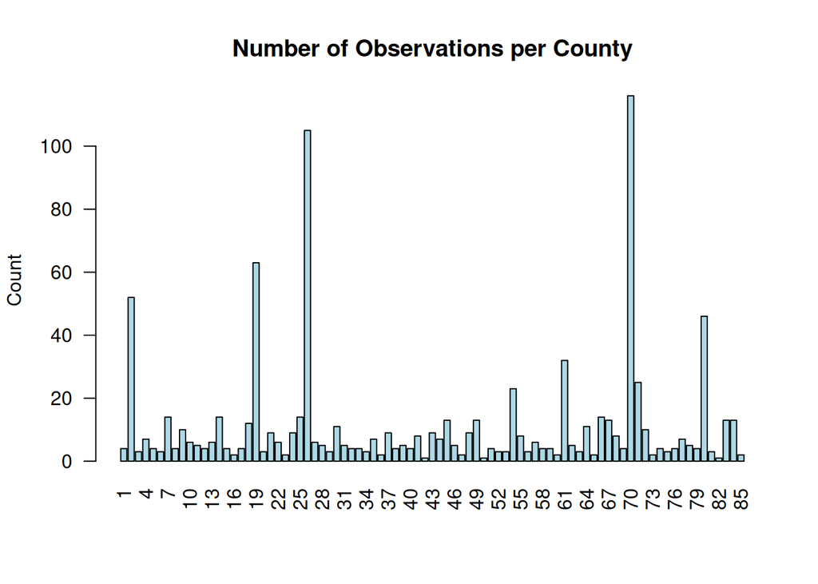

```r
barplot(
  xtabs(~ county, df),
  las = 2,                # rotate county labels for readability
  col = "lightblue",
  main = "Number of Observations per County",
  ylab = "Count"
)
```

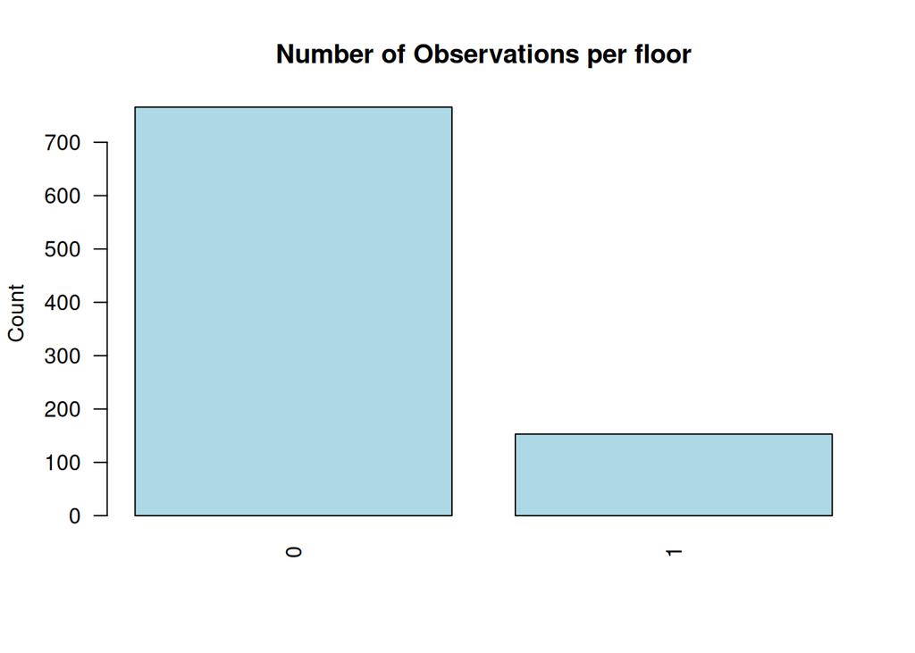

```r
barplot(
  xtabs(~ floor, df),
  las = 2,                # rotate county labels for readability
  col = "lightblue",
  main = "Number of Observations per floor",
  ylab = "Count"
)
```

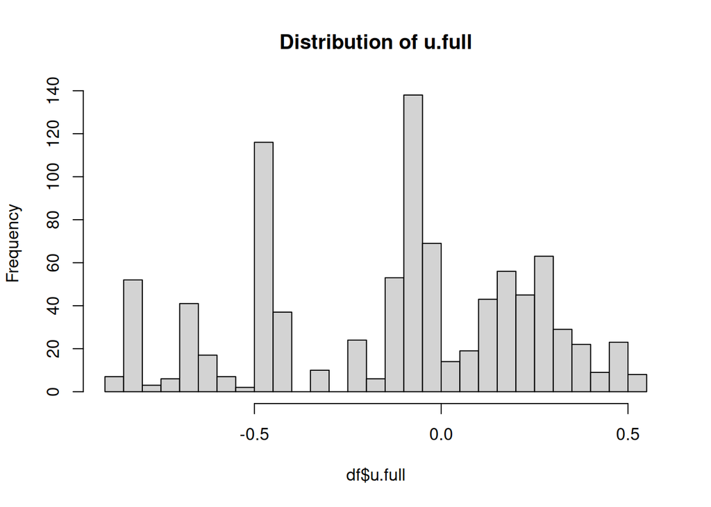

```r
hist(df$u.full, breaks = 50, col = "lightgray", main = "Distribution of u.full")
```

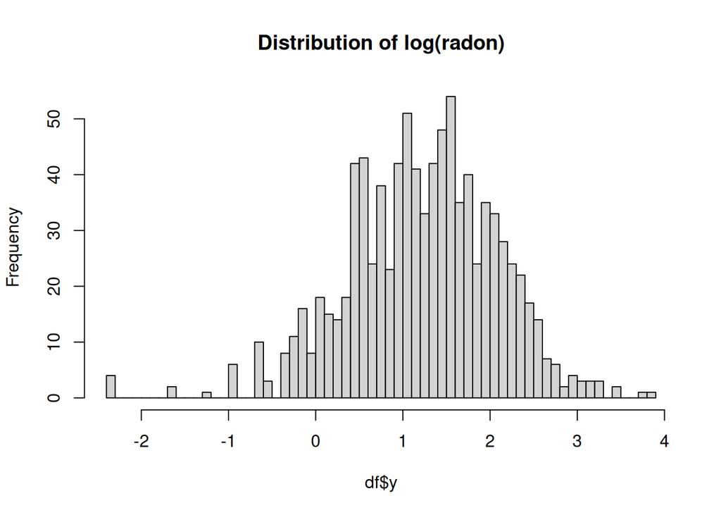

```r
hist(df$y, breaks = 50, col = "lightgray", main = "Distribution of log(radon)")
```

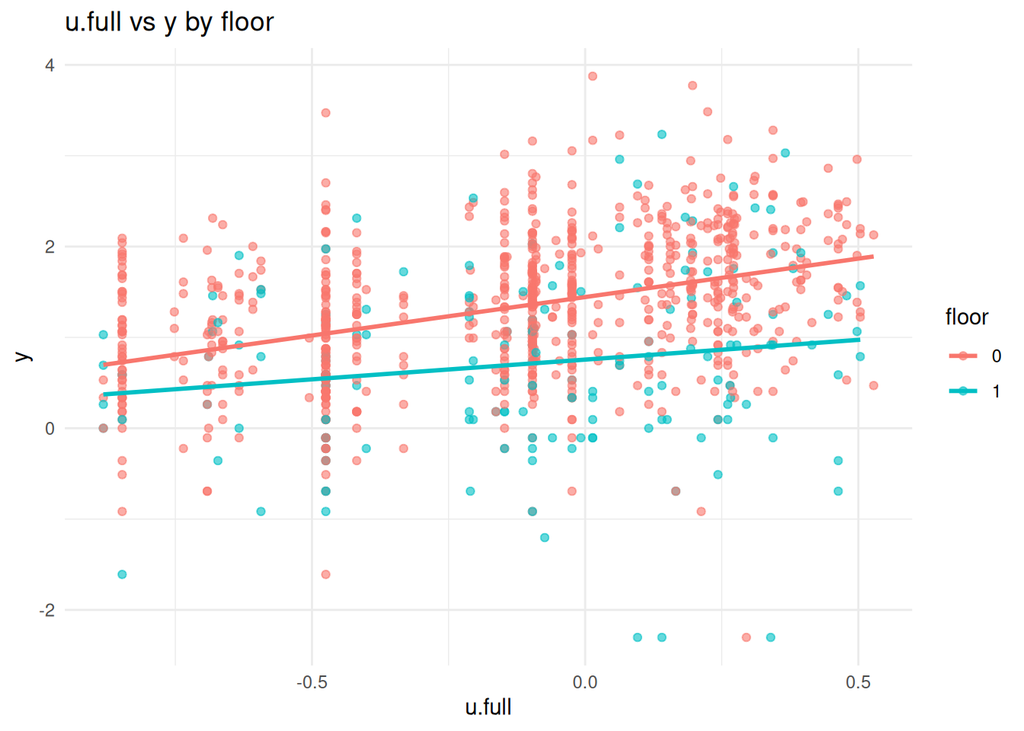

```r
ggplot(df, aes(x = u.full, y = y, color = floor)) +
  geom_point(alpha = 0.6) +
  geom_smooth(method = "lm", se = FALSE) +
  theme_minimal() +
  labs(title = "u.full vs y by floor")
```

```r
cor(df[, c("u.full", "y")])
```

```
##           u.full         y
## u.full 1.0000000 0.3219591
## y      0.3219591 1.0000000
```

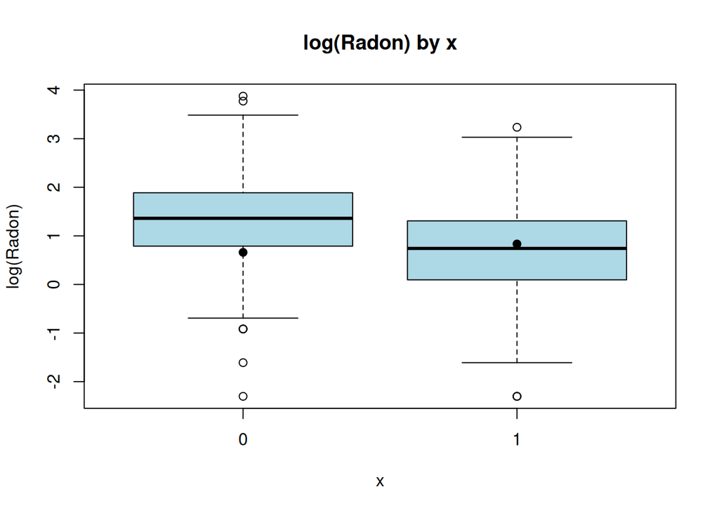

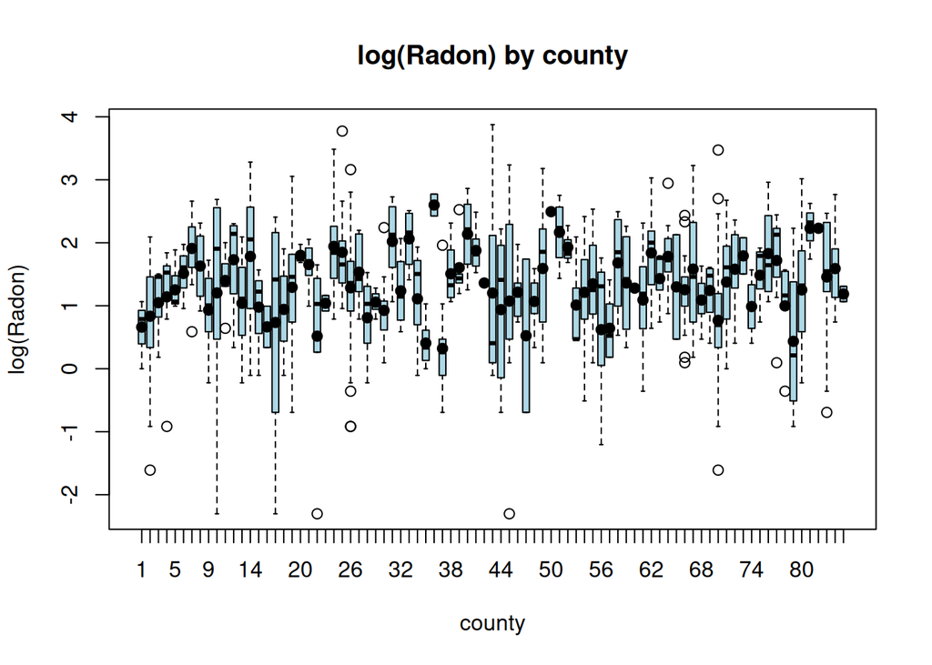

```r
vars <- c("x", "county")

# par(mfrow = c(2, 2))

for (v in vars) {
  formula <- as.formula(paste("y ~", v))

  boxplot(formula, data = df,
          main = paste("log(Radon) by", v),
          xlab = v,
          ylab = "log(Radon)",
          col = "lightblue")

          means <- tapply(df$y, df$county, mean)
          points(1:length(means), means, pch = 19, col = "black")

  }
```

```r
par(mfrow = c(1, 1))
```

It’s not clear whethere there is a significant between group variance, we see that we have overlap between the inter quartile ranges for the two groups.

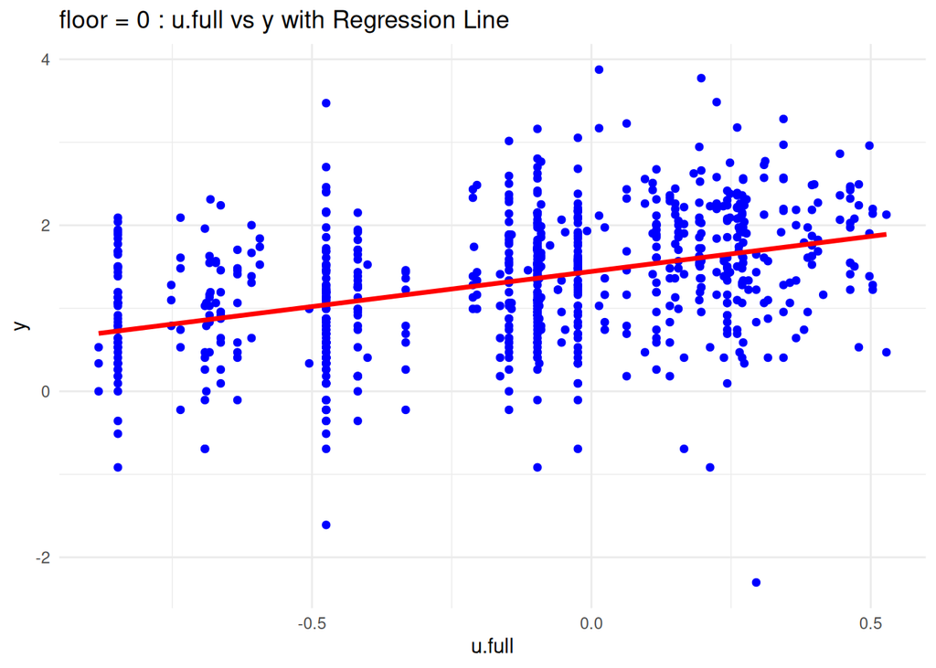

```r
radon_floor_0 <- df %>%
  filter(floor == 0)

ggplot(radon_floor_0, aes(x = u.full, y = y)) +
  geom_point(color = "blue") +
  geom_smooth(method = "lm", se = FALSE, color = "red", linewidth = 1.2) +
  labs(
    x = "u.full",
    y = "y",
    title = "floor = 0 : u.full vs y with Regression Line"
  ) +
  theme_minimal()
```

```r
model <- lm(y ~ u.full, data = radon_floor_0)
summary(model)
```

```
##
## Call:
## lm(formula = y ~ u.full, data = radon_floor_0)
##
## Residuals:
##     Min      1Q  Median      3Q     Max
## -3.9963 -0.4546  0.0371  0.4725  2.4296
##
## Coefficients:
##             Estimate Std. Error t value Pr(>|t|)
## (Intercept)  1.44407    0.02779   51.97   <2e-16 ***
## u.full       0.84628    0.07099   11.92   <2e-16 ***
## ---
## Signif. codes:  0 '***' 0.001 '**' 0.01 '*' 0.05 '.' 0.1 ' ' 1
##
## Residual standard error: 0.7192 on 764 degrees of freedom
## Multiple R-squared:  0.1568, Adjusted R-squared:  0.1557
## F-statistic: 142.1 on 1 and 764 DF,  p-value: < 2.2e-16
```

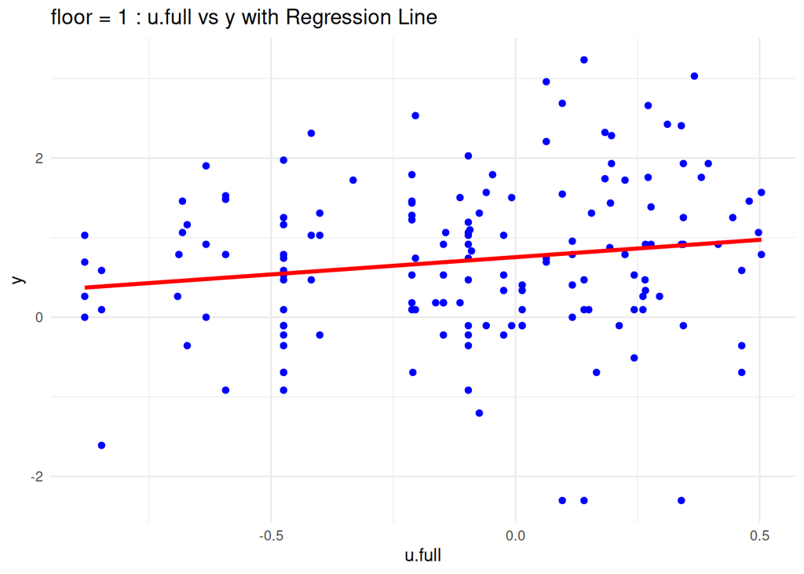

```r
radon_floor_0 <- df %>%
  filter(floor == 1)

ggplot(radon_floor_0, aes(x = u.full, y = y)) +
  geom_point(color = "blue") +
  geom_smooth(method = "lm", se = FALSE, color = "red", linewidth = 1.2) +
  labs(
    x = "u.full",
    y = "y",
    title = "floor = 1 : u.full vs y with Regression Line"
  ) +
  theme_minimal()
```

```r
model <- lm(y ~ u.full, data = radon_floor_0)
summary(model)
```

```
##
## Call:
## lm(formula = y ~ u.full, data = radon_floor_0)
##
## Residuals:
##     Min      1Q  Median      3Q     Max
## -3.2056 -0.6213  0.0132  0.6176  2.4182
##
## Coefficients:
##             Estimate Std. Error t value Pr(>|t|)
## (Intercept)  0.75550    0.08294   9.109 4.71e-16 ***
## u.full       0.43457    0.22326   1.946   0.0535 .
## ---
## Signif. codes:  0 '***' 0.001 '**' 0.01 '*' 0.05 '.' 0.1 ' ' 1
##
## Residual standard error: 0.9903 on 151 degrees of freedom
## Multiple R-squared:  0.02448,    Adjusted R-squared:  0.01802
## F-statistic: 3.789 on 1 and 151 DF,  p-value: 0.05345
```

# II. Modeling

## Building the model

Target : y Uranium : u.full Floor : x County : county ### Model 0 - Mean We start with a simple model and build up from there. We see that the mean is signifincantly different from 0. We do not accept $ H_0 : = 0 $
$$y_{i} = \mu + \epsilon_i, \epsilon_i
\sim N(0, \sigma^2)$$

```r
model_0 <- lm(y ~ 1, df)
anova(model_0)
```

```
## Analysis of Variance Table
##
## Response: y
##            Df Sum Sq Mean Sq F value Pr(>F)
## Residuals 918 668.46 0.72817
```

```r
summary(model_0)
```

```
##
## Call:
## lm(formula = y ~ 1, data = df)
##
## Residuals:
##     Min      1Q  Median      3Q     Max
## -3.5272 -0.5828  0.0563  0.5671  2.6507
##
## Coefficients:
##             Estimate Std. Error t value Pr(>|t|)
## (Intercept)  1.22462    0.02815   43.51   <2e-16 ***
## ---
## Signif. codes:  0 '***' 0.001 '**' 0.01 '*' 0.05 '.' 0.1 ' ' 1
##
## Residual standard error: 0.8533 on 918 degrees of freedom
```

### Model 1 - Floor

$$y_{i} = \mu + \alpha_i + \epsilon_i ,
\quad \epsilon_i \sim N(0, \sigma^2)$$

```r
model_1 <- lm(y ~ floor, df)
anova(model_1)
```

```
## Analysis of Variance Table
##
## Response: y
##            Df Sum Sq Mean Sq F value    Pr(>F)
## floor       1  47.98  47.983  70.914 < 2.2e-16 ***
## Residuals 917 620.47   0.677
## ---
## Signif. codes:  0 '***' 0.001 '**' 0.01 '*' 0.05 '.' 0.1 ' ' 1
```

### Model 2 - Uranium

$$y_{i} = \mu + \alpha_i + \beta x_i+
\epsilon_i , \quad \epsilon_i \sim N(0, \sigma^2)$$

```r
model_2 <- lm(y ~ floor + u.full , df)
anova(model_2)
```

```
## Analysis of Variance Table
##
## Response: y
##            Df Sum Sq Mean Sq F value    Pr(>F)
## floor       1  47.98  47.983  80.489 < 2.2e-16 ***
## u.full      1  74.41  74.412 124.824 < 2.2e-16 ***
## Residuals 916 546.06   0.596
## ---
## Signif. codes:  0 '***' 0.001 '**' 0.01 '*' 0.05 '.' 0.1 ' ' 1
```

### Model 3 - Random effect

$$y_{i} = \mu + \alpha_i + \beta x_i +
\gamma_i + \epsilon_i , \quad \epsilon_i \sim N(0, \sigma^2_{\epsilon}),
\quad \gamma_i \sim N(0, \sigma^2_{\gamma})$$

```r
model_3 <- lmer(y ~ floor + u.full + (1|county) , df)
ranova(model_3)
```

```
## ANOVA-like table for random-effects: Single term deletions
##
## Model:
## y ~ floor + u.full + (1 | county)
##              npar  logLik    AIC    LRT Df Pr(>Chisq)
## <none>          5 -1067.1 2144.2
## (1 | county)    4 -1071.1 2150.1 7.9559  1   0.004793 **
## ---
## Signif. codes:  0 '***' 0.001 '**' 0.01 '*' 0.05 '.' 0.1 ' ' 1
```

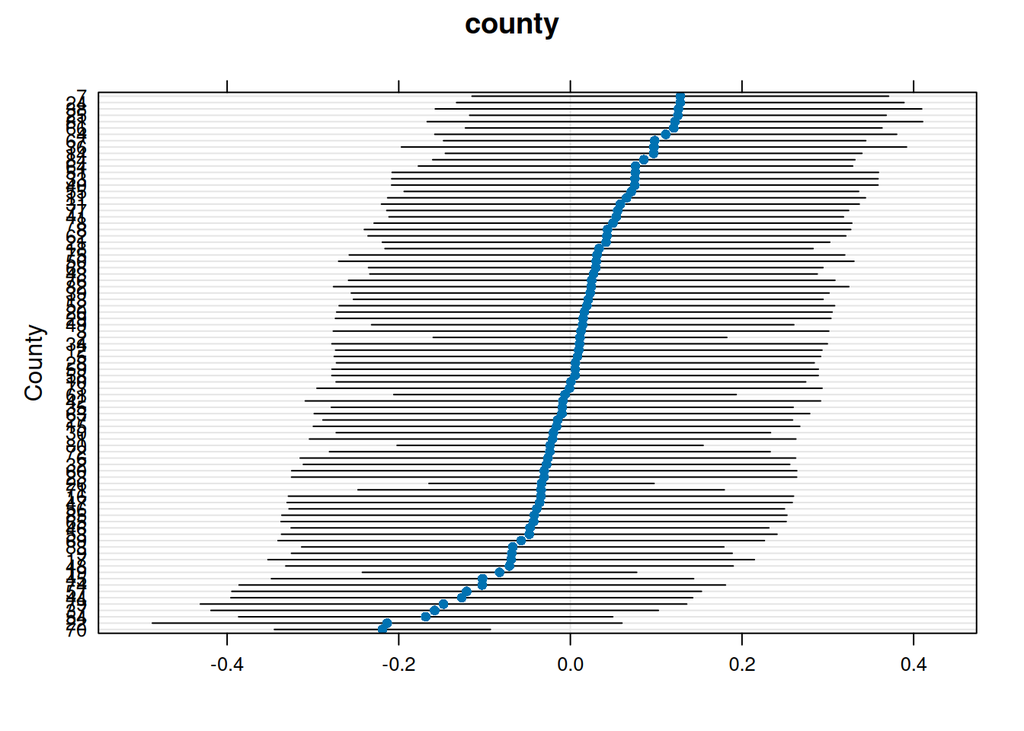

```r
dotplot(ranef(model_3, condVar=TRUE), strip = FALSE, ylab="County")
```

```r
ranef_model_3 <- ranef(model_3, condVar=TRUE)
```

### Model 4 & 5 - Random slopes

We add a random slope to the model to allow the impact of the fixed effects to vary across county.

**Random slope for predictor floor** By including a random slope for the predictor x, we allow its effect on radon levels to depend on the county. This tests whether counties differ in how strongly basement measurements raise or lower radon levels.

```r
model_4 <- lmer(y ~ x + u.full + (x|county) , df)
ranova(model_4)
```

```
## ANOVA-like table for random-effects: Single term deletions
##
## Model:
## y ~ x + u.full + (x | county)
##                   npar  logLik    AIC    LRT Df Pr(>Chisq)
## <none>               7 -1064.3 2142.6
## x in (x | county)    5 -1067.1 2144.2 5.5459  2    0.06248 .
## ---
## Signif. codes:  0 '***' 0.001 '**' 0.01 '*' 0.05 '.' 0.1 ' ' 1
```

The addition of a random-slope term is not statistically significant (p = 0.062). Therefore, the basement effect appears to be consistent across counties, and the random-intercept model is adequate.

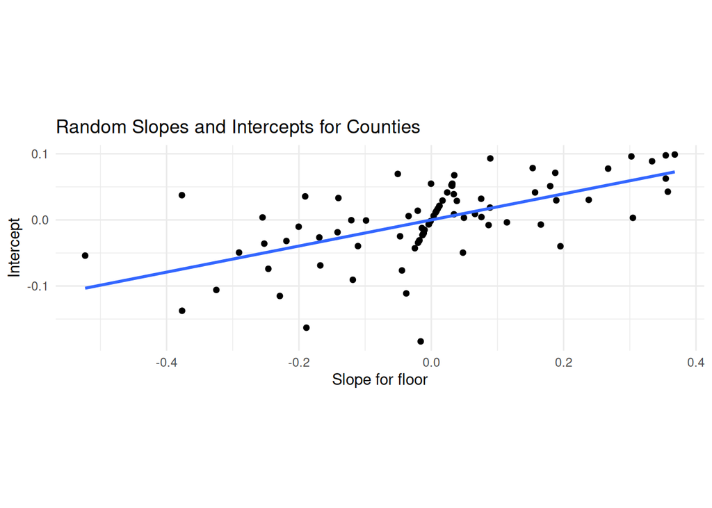

```r
ranef_m4 <- ranef(model_4)$county
library(ggplot2)
ggplot(ranef_m4, aes(x = x, y = `(Intercept)`)) +
  geom_point() +
  geom_smooth(method = "lm",
              se = FALSE) +
  labs(title = "Random Slopes and Intercepts for Counties",
       x = "Slope for floor",
       y = "Intercept") +
#  xlim(-0.6, 0.6) +
#  ylim(-0.4, 0.4) +
  coord_fixed() +   # <-- makes width = height
  theme_minimal()
```

The above graph show the the slopes and intercept for each cluster. We don’t see clear patterns in the points exeot one straight line. I won’t look into further detail as the effect of the random slope are not significant.

**Random slope for predictor u.full** We skip this since there is no within-county variation.

### Full model

$$y_{i} = \mu + \alpha_i + \beta x_i +
\gamma_i + \epsilon_i , \quad \epsilon_i \sim N(0, \sigma^2_{\epsilon}),
\quad \gamma_i \sim N(0, \sigma^2_{\gamma})$$

```r
model <- lmer(y ~ floor + u.full + (1|county) , df)
summary(model)
```

```
## Linear mixed model fit by REML. t-tests use Satterthwaite's method [
## lmerModLmerTest]
## Formula: y ~ floor + u.full + (1 | county)
##    Data: df
##
## REML criterion at convergence: 2134.2
##
## Scaled residuals:
##     Min      1Q  Median      3Q     Max
## -4.9673 -0.6117  0.0274  0.6555  3.3848
##
## Random effects:
##  Groups   Name        Variance Std.Dev.
##  county   (Intercept) 0.02446  0.1564
##  Residual             0.57523  0.7584
## Number of obs: 919, groups:  county, 85
##
## Fixed effects:
##              Estimate Std. Error        df t value Pr(>|t|)
## (Intercept)   1.46576    0.03794  55.34577  38.633  < 2e-16 ***
## floor1       -0.66824    0.06880 902.87114  -9.713  < 2e-16 ***
## u.full        0.72027    0.09176  45.99114   7.849 4.94e-10 ***
## ---
## Signif. codes:  0 '***' 0.001 '**' 0.01 '*' 0.05 '.' 0.1 ' ' 1
##
## Correlation of Fixed Effects:
##        (Intr) floor1
## floor1 -0.357
## u.full  0.145 -0.009
```

$$\hat{\sigma_{\epsilon}} = 0.7584, \quad
\hat{\sigma_{\gamma}} = 0.1564$$
We see that only 4 % of the variance is explained by the random effect.
$$\frac{0.024}{0.575 + 0.024} = 4 \%$$

```r
confint(model)
```

```
## Computing profile confidence intervals ...
```

```
##                   2.5 %     97.5 %
## .sig01       0.05277016  0.2454198
## .sigma       0.72351612  0.7957389
## (Intercept)  1.39137411  1.5415136
## floor1      -0.80224373 -0.5307890
## u.full       0.53732370  0.8992722
```

Given our observation we are 95% confident that the population mean $\hat{\mu}$ are between (1.39, 1.54) given floor = 0 and u.full = 0. The slope $ $ are between (0.54, 0.90). And that the effect of floor=1 are between (-08, -0.53)

## Diagnostics

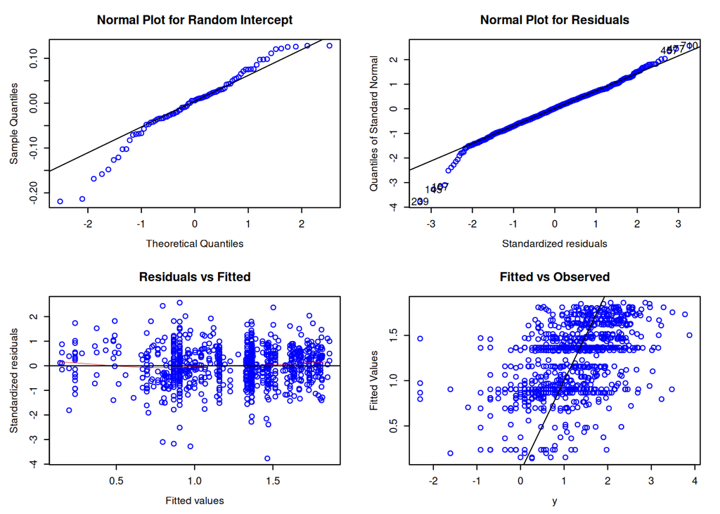

```r
residplot(model)
```

```r
df[299, ]
```

```
##     idnum state state2 stfips   zip region typebldg floor room basement windoor
## 299  5379    MN     MN     27 55413      3        1     0    4        Y      NA
##     rep stratum wave starttm stoptm startdt stopdt activity pcterr    adjwt
## 299   2       5   37    2000   2000   11088  11288      1.9    9.8 2246.969
##     dupflag zipflag cntyfips county x          county.name         y
## 299       0       0       53     26 0 HENNEPIN             0.6418539
##          u.full
## 299 -0.09652081
```

```r
df[149, ]
```

```
##     idnum state state2 stfips   zip region typebldg floor room basement windoor
## 149  5229    MN     MN     27 56401      2        1     1    2               NA
##     rep stratum wave starttm stoptm startdt stopdt activity pcterr    adjwt
## 149   4       3   44     900    900   12388  12588        1   18.7 990.4116
##     dupflag zipflag cntyfips county x          county.name y     u.full
## 149       1       0       35     18 1 CROW WING            0 -0.6333907
```

```r
predict(model, newdata = df[299, ])
```

```
##     299
## 1.36263
```

```r
predict(model, newdata = df[149, ])
```

```
##       149
## 0.3747311
```

```r
predict(model, newdata = df[299, ], re.form = NA)
```

```
##      299
## 1.396242
```

```r
predict(model, newdata = df[149, ], re.form = NA)
```

```
##       149
## 0.3413072
```

## Comparison

Look at the change to the diagnostic plots as complexity increasses

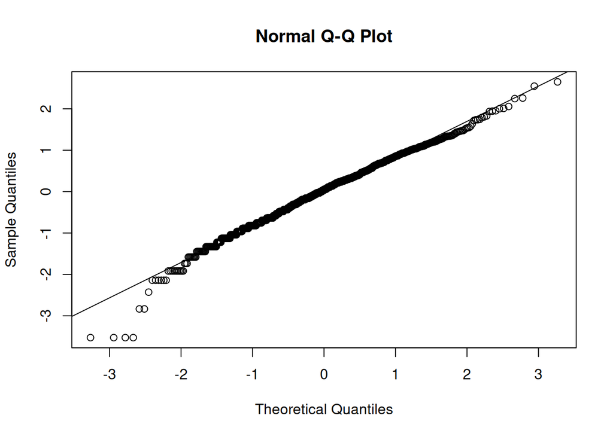

```r
qqnorm(resid(model_0))
qqline(resid(model_0))
```

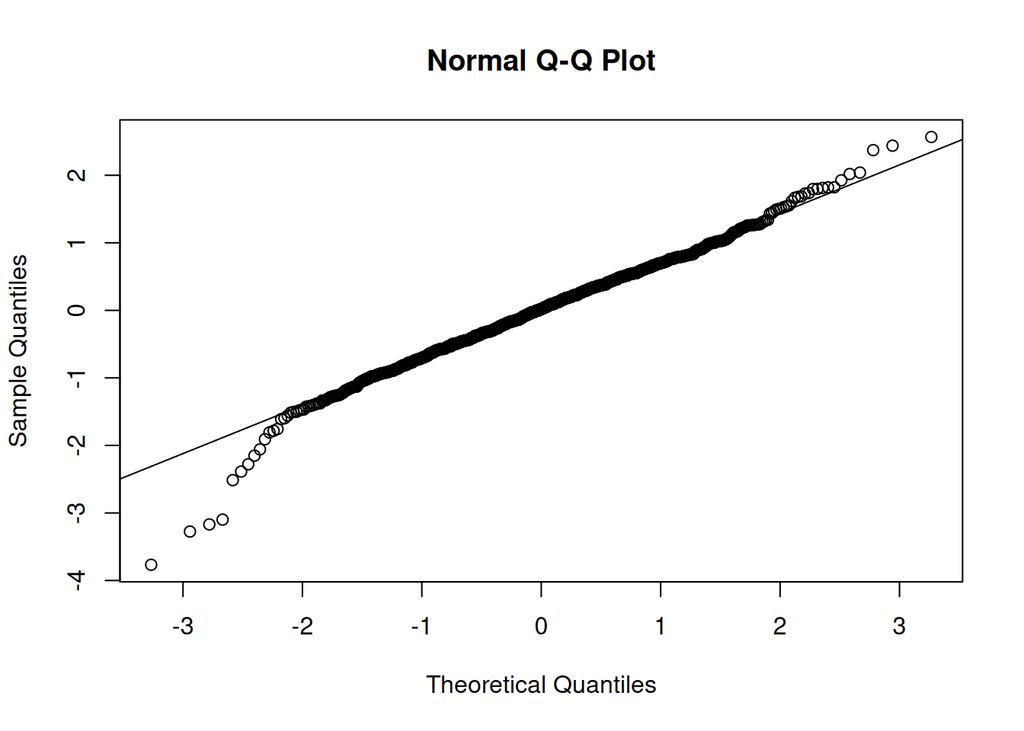

```r
qqnorm(resid(model_3))
qqline(resid(model_3))
```

Comparison table

```r
AIC(model_0, model_1, model_2, model_3)
```

```
##         df      AIC
## model_0  2 2319.479
## model_1  3 2253.025
## model_2  4 2137.621
## model_3  5 2144.186
```

```r
BIC(model_0, model_1, model_2, model_3)
```

```
##         df      BIC
## model_0  2 2329.126
## model_1  3 2267.495
## model_2  4 2156.914
## model_3  5 2168.303
```

```r
logLik(model_0)
```

```
## 'log Lik.' -1157.74 (df=2)
```

```r
logLik(model_1)
```

```
## 'log Lik.' -1123.512 (df=3)
```

```r
logLik(model_2)
```

```
## 'log Lik.' -1064.81 (df=4)
```

```r
logLik(model_3)
```

```
## 'log Lik.' -1067.093 (df=5)
```

| Model | df | logLik | AIC | BIC |
| --- | --- | --- | --- | --- |
| model_0 | 2 | –1157.740 | 2319.479 | 2329.126 |
| model_1 | 3 | –1123.512 | 2253.025 | 2267.495 |
| model_2 | 4 | –1064.810 | 2137.621 | 2156.914 |
| model_3 | 5 | –1067.093 | 2144.186 | 2168.303 |

Even though the variance of the residuals decrease from $0.772^2 = 0.596$ in model_2 to $0.758^2 = 0.575$ in model_3, we get an additional variance from the random effect of $0.156^2 = 0.024$ meaning that the overall variance increases hich decreasses the log-likeyhood function.

```r
summary(model_2)
```

```
##
## Call:
## lm(formula = y ~ floor + u.full, data = df)
##
## Residuals:
##     Min      1Q  Median      3Q     Max
## -3.9676 -0.4809  0.0267  0.4993  2.4297
##
## Coefficients:
##             Estimate Std. Error t value Pr(>|t|)
## (Intercept)  1.43489    0.02953  48.593   <2e-16 ***
## floor1      -0.64589    0.06843  -9.438   <2e-16 ***
## u.full       0.78004    0.06982  11.172   <2e-16 ***
## ---
## Signif. codes:  0 '***' 0.001 '**' 0.01 '*' 0.05 '.' 0.1 ' ' 1
##
## Residual standard error: 0.7721 on 916 degrees of freedom
## Multiple R-squared:  0.1831, Adjusted R-squared:  0.1813
## F-statistic: 102.7 on 2 and 916 DF,  p-value: < 2.2e-16
```

```r
summary(model_3)
```

```
## Linear mixed model fit by REML. t-tests use Satterthwaite's method [
## lmerModLmerTest]
## Formula: y ~ floor + u.full + (1 | county)
##    Data: df
##
## REML criterion at convergence: 2134.2
##
## Scaled residuals:
##     Min      1Q  Median      3Q     Max
## -4.9673 -0.6117  0.0274  0.6555  3.3848
##
## Random effects:
##  Groups   Name        Variance Std.Dev.
##  county   (Intercept) 0.02446  0.1564
##  Residual             0.57523  0.7584
## Number of obs: 919, groups:  county, 85
##
## Fixed effects:
##              Estimate Std. Error        df t value Pr(>|t|)
## (Intercept)   1.46576    0.03794  55.34577  38.633  < 2e-16 ***
## floor1       -0.66824    0.06880 902.87114  -9.713  < 2e-16 ***
## u.full        0.72027    0.09176  45.99114   7.849 4.94e-10 ***
## ---
## Signif. codes:  0 '***' 0.001 '**' 0.01 '*' 0.05 '.' 0.1 ' ' 1
##
## Correlation of Fixed Effects:
##        (Intr) floor1
## floor1 -0.357
## u.full  0.145 -0.009
```

# III. Results

## III a) Present a plot analogous to the one in Figure 1, with the estimated response means per county

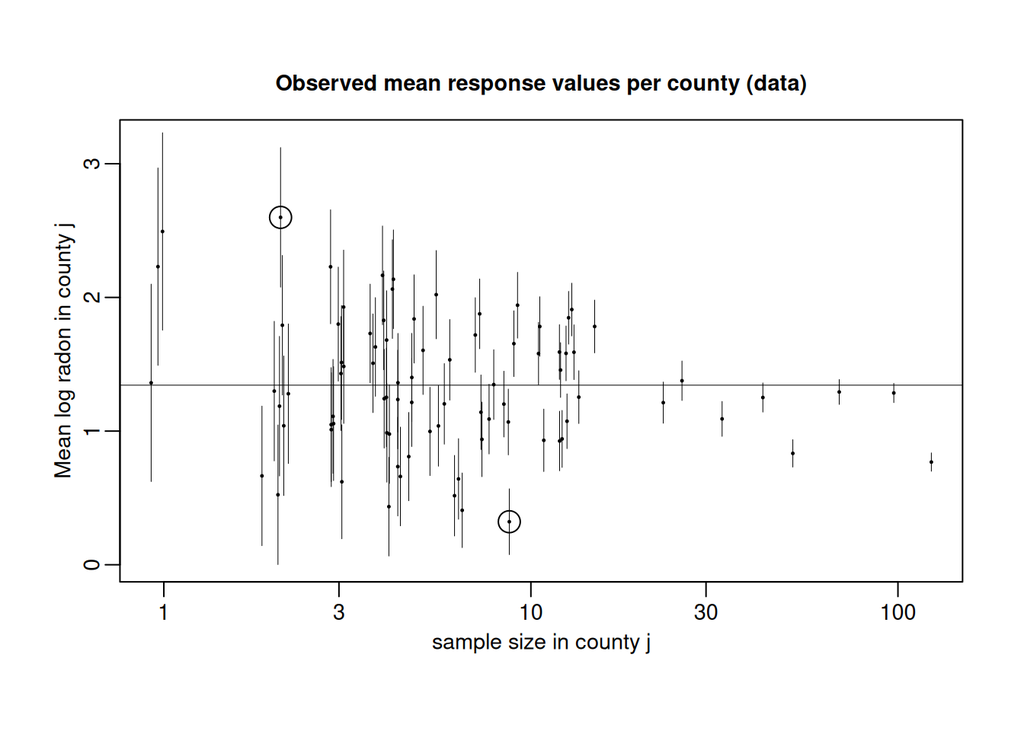

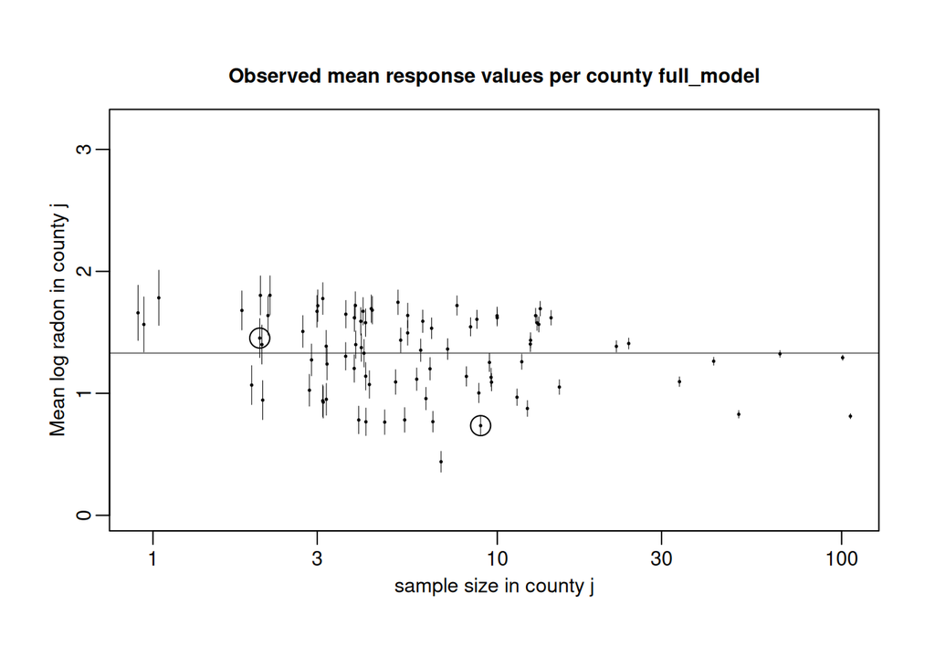

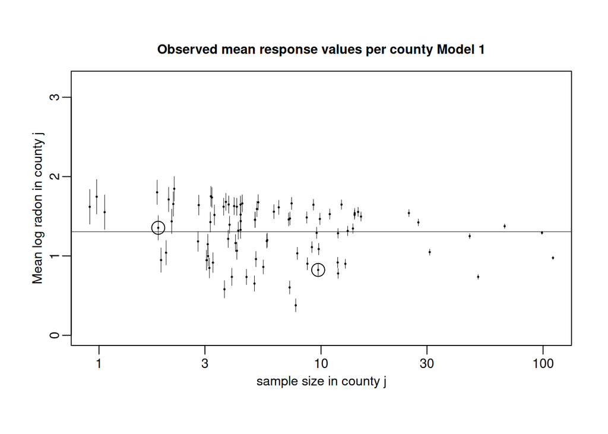

```r
model <- lmer(y ~ floor + u.full + (1|county) , df)
df_pred <- df
df_pred_before_random <- df
df_pred$y <- predict(model, newdata = df)
df_pred_before_random$y <- predict(model_2, newdata = df)



invisible({
  attach(df)
  (J <- length(unique(county.name)))
  (ybarbar = mean(y))

  (sample.size <- as.vector(table(county)))
  (sample.size.jittered <- sample.size*exp(runif (J, -.1, .1)))
  (cty.mns = tapply(y,county,mean))
  (cty.vars = tapply(y,county,var))
  (cty.sds = mean(sqrt(cty.vars[!is.na(cty.vars)]))/sqrt(sample.size))
  (cty.sds.sep = sqrt(tapply(y,county,var)/sample.size))

  par(mfrow=c(1,1))
  plot (sample.size.jittered, cty.mns, cex.lab=.9, cex.axis=1,
        xlab="sample size in county j",
        ylab="Mean log radon in county j",
        pch=20, log="x", cex=.3, mgp=c(1.5,.5,0),
        ylim=c(0,3.2), yaxt="n", xaxt="n")
  axis (1, c(1,3,10,30,100), cex.axis=.9, mgp=c(1.5,.5,0))
  axis (2, seq(0,3), cex.axis=.9, mgp=c(1.5,.5,0))
  for (j in 1:J){
    lines (rep(sample.size.jittered[j],2),
           cty.mns[j] + c(-1,1)*cty.sds[j], lwd=.5)
    #         cty.mns[j] + c(-1,1)*mean(cty.sds[!is.na(cty.sds)]), lwd=.5)
  }
  abline(h=mean(cty.mns),lwd=.5 )
  title("Observed mean response values per county (data)",cex.main=.9, line=1)

  cty.mns[cty.mns==max(cty.mns)]
  cty.mns[cty.mns==min(cty.mns)]

  points(sample.size.jittered[36],cty.mns[36],cex=2) #max
  points(sample.size.jittered[37],cty.mns[37],cex=2) #min
  detach(df)

  attach(df_pred)
  (J <- length(unique(county.name)))
  (ybarbar = mean(y))

  (sample.size <- as.vector(table(county)))
  (sample.size.jittered <- sample.size*exp(runif (J, -.1, .1)))
  (cty.mns = tapply(y,county,mean))
  (cty.vars = tapply(y,county,var))
  (cty.sds = mean(sqrt(cty.vars[!is.na(cty.vars)]))/sqrt(sample.size))
  (cty.sds.sep = sqrt(tapply(y,county,var)/sample.size))

  par(mfrow=c(1,1))
  plot (sample.size.jittered, cty.mns, cex.lab=.9, cex.axis=1,
        xlab="sample size in county j",
        ylab="Mean log radon in county j",
        pch=20, log="x", cex=.3, mgp=c(1.5,.5,0),
        ylim=c(0,3.2), yaxt="n", xaxt="n")
  axis (1, c(1,3,10,30,100), cex.axis=.9, mgp=c(1.5,.5,0))
  axis (2, seq(0,3), cex.axis=.9, mgp=c(1.5,.5,0))
  for (j in 1:J){
    lines (rep(sample.size.jittered[j],2),
           cty.mns[j] + c(-1,1)*cty.sds[j], lwd=.5)
    #         cty.mns[j] + c(-1,1)*mean(cty.sds[!is.na(cty.sds)]), lwd=.5)
  }
  abline(h=mean(cty.mns),lwd=.5 )
  title("Observed mean response values per county full_model",cex.main=.9, line=1)

  cty.mns[cty.mns==max(cty.mns)]
  cty.mns[cty.mns==min(cty.mns)]

  points(sample.size.jittered[36],cty.mns[36],cex=2) #max
  points(sample.size.jittered[37],cty.mns[37],cex=2) #min

  # print(cty.sds)

  detach(df_pred)

  attach(df_pred_before_random)
  (J <- length(unique(county.name)))
  (ybarbar = mean(y))

  (sample.size <- as.vector(table(county)))
  (sample.size.jittered <- sample.size*exp(runif (J, -.1, .1)))
  (cty.mns = tapply(y,county,mean))
  (cty.vars = tapply(y,county,var))
  (cty.sds = mean(sqrt(cty.vars[!is.na(cty.vars)]))/sqrt(sample.size))
  (cty.sds.sep = sqrt(tapply(y,county,var)/sample.size))

  par(mfrow=c(1,1))
  plot (sample.size.jittered, cty.mns, cex.lab=.9, cex.axis=1,
        xlab="sample size in county j",
        ylab="Mean log radon in county j",
        pch=20, log="x", cex=.3, mgp=c(1.5,.5,0),
        ylim=c(0,3.2), yaxt="n", xaxt="n")
  axis (1, c(1,3,10,30,100), cex.axis=.9, mgp=c(1.5,.5,0))
  axis (2, seq(0,3), cex.axis=.9, mgp=c(1.5,.5,0))
  for (j in 1:J){
    lines (rep(sample.size.jittered[j],2),
           cty.mns[j] + c(-1,1)*cty.sds[j], lwd=.5)
    #         cty.mns[j] + c(-1,1)*mean(cty.sds[!is.na(cty.sds)]), lwd=.5)
  }
  abline(h=mean(cty.mns),lwd=.5 )
  title("Observed mean response values per county Model 1",cex.main=.9, line=1)

  cty.mns[cty.mns==max(cty.mns)]
  cty.mns[cty.mns==min(cty.mns)]

  points(sample.size.jittered[36],cty.mns[36],cex=2) #max
  points(sample.size.jittered[37],cty.mns[37],cex=2) #min
  detach(df_pred_before_random)
})
```

There should be at max two differnt outcomes county

```r
df_pred %>%
  group_by(county) %>%
  summarise(n_unique_y = n_distinct(y)) %>% head(10)
```

```
## # A tibble: 10 × 2
##    county n_unique_y
##    <fct>       <int>
##  1 1               2
##  2 2               2
##  3 3               2
##  4 4               2
##  5 5               2
##  6 6               1
##  7 7               2
##  8 8               2
##  9 9               2
## 10 10              2
```

```r
df_pred %>%
  group_by(county) %>%
  summarise(
    y_values = list(sort(unique(y))),
    diff_y = diff(sort(unique(y)))
  ) %>% head(10)
```

```
## # A tibble: 10 × 3
## # Groups:   county [10]
##    county y_values  diff_y
##    <fct>  <list>     <dbl>
##  1 1      <dbl [2]>  0.668
##  2 2      <dbl [2]>  0.668
##  3 3      <dbl [2]>  0.668
##  4 4      <dbl [2]>  0.668
##  5 5      <dbl [2]>  0.668
##  6 7      <dbl [2]>  0.668
##  7 8      <dbl [2]>  0.668
##  8 9      <dbl [2]>  0.668
##  9 10     <dbl [2]>  0.668
## 10 14     <dbl [2]>  0.668
```

```r
overall_mean <- mean(df_pred$y)

df_pred %>%
  group_by(county) %>%
  summarise(
    county_mean = mean(y),
    diff_from_overall = county_mean - overall_mean
  ) %>%
  arrange(desc(diff_from_overall)) %>%
  head(10)
```

```
## # A tibble: 10 × 3
##    county county_mean diff_from_overall
##    <fct>        <dbl>             <dbl>
##  1 73            1.80             0.579
##  2 65            1.80             0.579
##  3 50            1.78             0.559
##  4 52            1.78             0.552
##  5 31            1.75             0.522
##  6 51            1.72             0.495
##  7 41            1.72             0.495
##  8 6             1.72             0.494
##  9 40            1.69             0.470
## 10 7             1.69             0.469
```

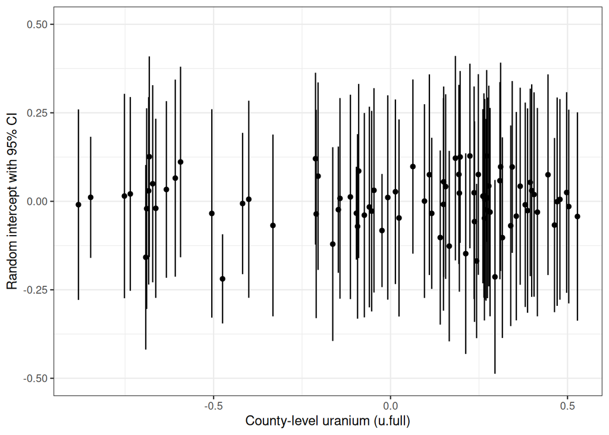

```r
model <- lmer(y ~ floor + u.full + (1|county) , df)

library(lme4)
library(ggplot2)

# Random intercepts with conditional variance
re  <- ranef(model, condVar=TRUE)
u   <- attr(re$county, "postVar")   # 1x1xN array of variances

# Random-intercept estimates
intercepts <- re$county[, "(Intercept)"]

# Std. errors from conditional modes
se <- sqrt(sapply(1:dim(u)[3], function(i) u[,,i]))

# Build dataframe
df_plot <- data.frame(
  county    = rownames(re$county),
  intercept = intercepts,
  lower     = intercepts - 1.96 * se,
  upper     = intercepts + 1.96 * se
)

u_by_county <- aggregate(u.full ~ county, data=df, FUN=unique)
names(u_by_county)[2] <- "u_full_county"

df_plot$u_full <- u_by_county$u_full_county[
  match(df_plot$county, u_by_county$county)
]

ggplot(df_plot, aes(x = u_full, y = intercept)) +
  geom_point() +
  geom_errorbar(aes(ymin = lower, ymax = upper), width = 0) +
  xlab("County-level uranium (u.full)") +
  ylab("Random intercept with 95% CI") +
  ylim(-0.5, 0.5) +
  theme_bw()
```

```r
# Posterior variance for each county's random intercept
post_var <- sapply(1:dim(u)[3], function(i) u[,,i])

# Build a dataframe with county, variance, SE, and intercept
var_by_county <- data.frame(
  county    = rownames(re$county),
  intercept = re$county[, "(Intercept)"],
  var       = post_var,
  se        = sqrt(post_var)
)

# Counties with the *lowest* conditional variance
var_by_county_lowest <- var_by_county %>%
  arrange(var)

# View the top few with lowest variance
head(var_by_county_lowest, 10)
```

```
##    county    intercept         var         se
## 1      70 -0.219046443 0.004123054 0.06421101
## 2      26 -0.033611813 0.004475958 0.06690260
## 3      19 -0.082565464 0.006648864 0.08154057
## 4       2  0.011245769 0.007617373 0.08727756
## 5      80 -0.023622969 0.008274841 0.09096615
## 6      61 -0.006241583 0.010361603 0.10179196
## 7      71 -0.034072808 0.011856612 0.10888807
## 8      54 -0.168591346 0.012366403 0.11120433
## 9       7  0.128109354 0.015333108 0.12382693
## 10     14  0.097050733 0.015333108 0.12382693
```

```r
var_by_county_highest <- var_by_county %>%
  arrange(desc(var))

# View the top counties with the largest variance
head(var_by_county_highest, 10)
```

```
##    county    intercept        var        se
## 1      42 -0.008669534 0.02346388 0.1531792
## 2      50  0.030191589 0.02346388 0.1531792
## 3      82  0.024239392 0.02346388 0.1531792
## 4      16 -0.034266810 0.02254429 0.1501475
## 5      23 -0.030629813 0.02254429 0.1501475
## 6      36  0.097433110 0.02254429 0.1501475
## 7      47 -0.035796332 0.02254429 0.1501475
## 8      60 -0.030481513 0.02254429 0.1501475
## 9      65 -0.042872991 0.02254429 0.1501475
## 10     73 -0.001026018 0.02254429 0.1501475
```

```r
# 6 in sample
# 6 out of sample

new_data <- data.frame(
  county = c(
            35,35,
            43,43,
            65,65,
            100,100,
            101,101,
            102,102
            ),
  floor  = c(
            0,1,
            0,1,
            0,1,
            0,1,
            0,1,
            0,1
            ),
  u.full = c(
            -0.8818289, -0.8818289,
            0.013764829,0.013764829,
            0.52802487,0.52802487,
            -1,-1,
            0,0,
            0.7,0.7
            )
)


new_data$floor  <- factor(new_data$floor)
new_data$county <- factor(new_data$county)
new_data$pred_conditional <- predict(model_3, newdata = new_data, re.form = NA)

new_data
```

```
##    county floor      u.full pred_conditional
## 1      35     0 -0.88182890       0.83061001
## 2      35     1 -0.88182890       0.16236525
## 3      43     0  0.01376483       1.47567717
## 4      43     1  0.01376483       0.80743241
## 5      65     0  0.52802487       1.84608202
## 6      65     1  0.52802487       1.17783726
## 7     100     0 -1.00000000       0.74549519
## 8     100     1 -1.00000000       0.07725043
## 9     101     0  0.00000000       1.46576281
## 10    101     1  0.00000000       0.79751805
## 11    102     0  0.70000000       1.96995014
## 12    102     1  0.70000000       1.30170538
```

```r
# install.packages("merTools")
library(merTools)
new_data$floor  <- factor(new_data$floor)
new_data$county <- factor(new_data$county)

pred_ci <- predictInterval(
  model,
  newdata = new_data,
  which   = "full",
  level   = 0.95,
  n.sims  = 1000,
  include.resid.var = TRUE
)
new_data <- cbind(new_data, pred_ci)
```

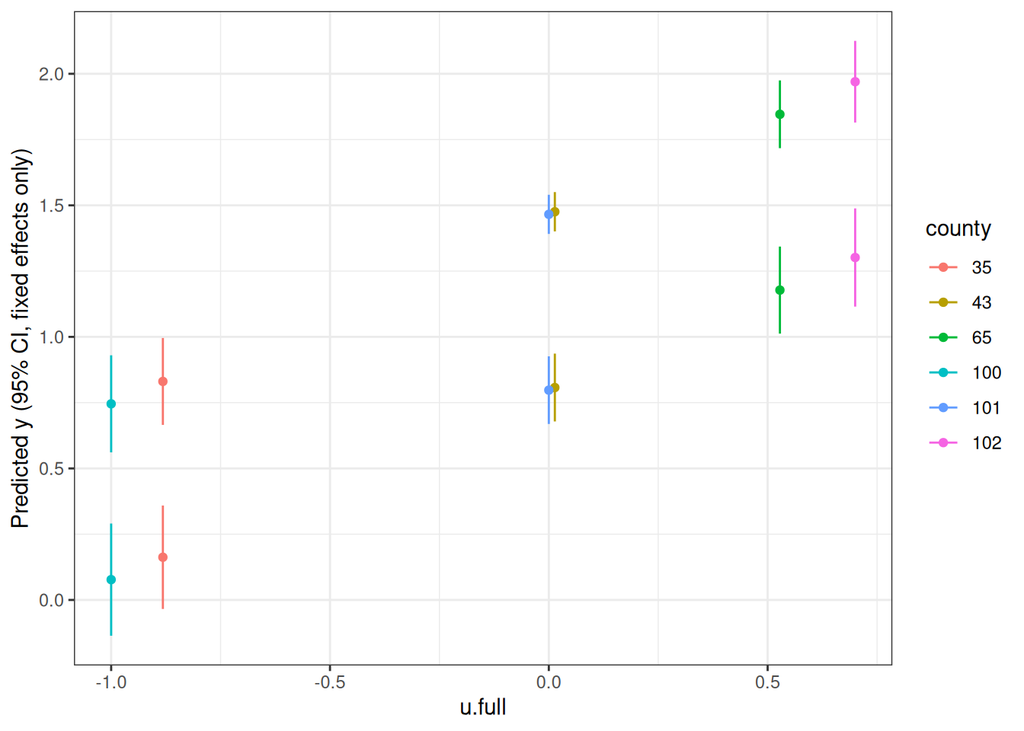

```r
library(lme4)

## Design matrix for the fixed-effects part of the model
## This must match the fixed-effects formula: ~ floor + u.full
X <- model.matrix(~ floor + u.full, data = new_data)

## Fixed-effect estimates and their covariance matrix
beta_hat <- fixef(model)
V_beta   <- vcov(model)

## Standard errors of the linear predictor X * beta
pred_se <- sqrt(diag(X %*% V_beta %*% t(X)))

## 95% confidence intervals
new_data$pred_se  <- pred_se
new_data$lower_ci <- new_data$pred_conditional - 1.96 * pred_se
new_data$upper_ci <- new_data$pred_conditional + 1.96 * pred_se

library(ggplot2)

ggplot(new_data, aes(x = u.full, y = pred_conditional, colour = county)) +
  geom_point() +
  geom_errorbar(aes(ymin = lower_ci, ymax = upper_ci), width = 0) +
  xlab("u.full") +
  ylab("Predicted y (95% CI, fixed effects only)") +
  theme_bw()
```